PHY-3500 — Physique numérique

# TP 3

### Équipe de recherche

**Alex Baker** — 537 050 929  
**Justine Jean** — 537 287 332  
**Nerimantas Caillat** — 537 396 153

### Informations académiques

**Cours :** PHY-3500 – Physique numérique (H26)  
**Remise :** 13 mars 2026  
**Encadrement :** Pr. Antoine Allard, Thomas Labbé, Philippe Després

## INTRODUCTION

### Objectif

L’objectif de ce troisième travail pratique est d’implémenter et d’analyser des méthodes numériques avancées appliquées à des problèmes issus de l’algèbre linéaire, de l’inférence statistique et de la modélisation non linéaire.

Dans un premier temps, nous implémentons la décomposition QR par la méthode de Householder et démontrons les propriétés d’orthogonalité des matrices de réflexion associées. Nous comparons ensuite notre implémentation aux fonctions natives de NumPy afin d’en valider la justesse et d’en discuter les différences éventuelles.

Dans un second temps, nous utilisons la décomposition QR réduite pour résoudre un problème de moindres carrés associé à des données expérimentales bruitées décrivant la trajectoire d’un projectile.

Finalement, nous étudions analytiquement et numériquement un modèle épidémiologique SIR sur réseau, en résolvant une équation cubique non linéaire à l’aide de différentes méthodes numériques et en analysant le comportement de la fraction finale d’individus infectés.

### Contexte

La décomposition QR consiste à écrire une matrice ( A ) sous la forme ( A = QR ), où ( Q ) est orthogonale et ( R ) est triangulaire supérieure. Bien que la méthode de Gram-Schmidt soit intuitive, elle est numériquement instable. La méthode de Householder, fondée sur des matrices de réflexion orthogonales, offre une meilleure stabilité et donc davantage utilié en pratique.

Dans le cas d’un système surdéterminé issu de mesures expérimentales bruitées, l’équation matricielle $ X\alpha = Y $ n’admet généralement pas de solution exacte. On cherche alors une solution approchée minimisant l’erreur quadratique $\|Y - X\alpha\|_2 $. Cette solution des moindres carrés s’obtient efficacement à l’aide de la décomposition QR réduite.

La dernière partie du travail porte sur un modèle SIR sur réseau décrivant la propagation d’une maladie infectieuse. La fraction finale d’individus infectés dépend d’une variable définie implicitement par une équation non linéaire. L’étude de cette équation permet d’illustrer les différences de convergence entre méthodes numériques itératives et d’interpréter physiquement l’existence éventuelle d’un seuil épidémique.

✦ ✦ ✦

1

## Décomposition QR par la méthode de Householder

**Mise en contexte :**

La décomposition QR consiste à factoriser une matrice $$ A \in \mathbb{R}^{m \times n} \quad (m \ge n) $$ sous la forme

$$ A = QR, $$

où \(Q\) est une matrice orthogonale (\(Q^TQ = I\)) et \(R\) est triangulaire supérieure. Cette factorisation joue un rôle central en algèbre linéaire numérique, notamment pour résoudre des systèmes surdéterminés et les problèmes de moindres carrés.

Le produit de ces réflexions permet ensuite de reconstruire la matrice \(Q\). Dans cette section, nous démontrons l’orthogonalité des matrices de réflexion, établissons la structure de \(Q\), puis implémentons l’algorithme afin de valider numériquement la décomposition (comparaison avec NumPy).

✦ ✦ ✦

1 a

## À l’aide des équations (3.2) et (3.3), démontrez que les matrices de réflexion Qi sont orthogonales.

Dans cette question nous cherchons à démontrer l'orthogonalité des matrices de réflexion de la décomposition QR, autrement dit :

$$ Q_i^TQ_i=I $$
Les matrices $Q_i$ sont par blocs diagonales,
$$ Q_i=\begin{bmatrix} I_i & 0\\ 0 & H_{m,i} \end{bmatrix} \tag{3.2} $$
Les transposées sont donc,
$$ Q_i^T=\begin{bmatrix} I_i^T & 0\\ 0 & H_{m,i}^T \end{bmatrix} $$
Le produit des matrices par blocs diagonales se fait bloc par bloc, nous avons donc,
$$ Q_i^TQ_i=\begin{bmatrix} I_i^TI_i & 0\\ 0 & H_{m,i}^TH_{m,i} \end{bmatrix} $$
Évidemment $I_i$ est orthogonale, $I_i^TI_i=I_i$, ainsi le problème se réduit à démontrer l'orthogonalité de $H_{m,i}$.
$$ H_{m,i}=I_{m-i}-2\frac{\mathbf{v}_{m,i}\mathbf{v}_{m,i}^T}{\mathbf{v}_{m,i}^T\mathbf{v}_{m,i}} \tag{3.3} $$
Avec $\frac{\mathbf{v}_{m,i}\mathbf{v}_{m,i}^T}{\mathbf{v}_{m,i}^T\mathbf{v}_{m,i}}$, le projecteur orthogonal du vecteur $\mathbf{v}_{m,i}$ de dimension $(m-i)\times1$
Par linéarité de la transposition,
$$ H_{m,i}^T=I_{m-i}^T-2\frac{(\mathbf{v}_{m,i}\mathbf{v}_{m,i}^T)^T}{\mathbf{v}_{m,i}^T\mathbf{v}_{m,i}} $$
Or $I_{m-i}^T=I_{m-i}$ et $(\mathbf{v}_{m,i}\mathbf{v}_{m,i}^T)^T=(\mathbf{v}_{m,i}\mathbf{v}_{m,i}^T)$ , donc on obtient,
$$ \begin{aligned} H_{m,i}^T&= I_{m-i}-2\frac{\mathbf{v}_{m,i}\mathbf{v}_{m,i}^T}{\mathbf{v}_{m,i}^T\mathbf{v}_{m,i}}\\ &= H_{m,i} \end{aligned} $$
$H_{m,i}$ est symétrique, donc,
$$ \begin{aligned} H_{m,i}^TH_{m,i}&= (H_{m,i})^2\\ &= \left(I_{m-i}-2\frac{\mathbf{v}_{m,i}\mathbf{v}_{m,i}^T}{\mathbf{v}_{m,i}^T\mathbf{v}_{m,i}}\right)^2\\ &= I_{m-i}-4\frac{\mathbf{v}_{m,i}\mathbf{v}_{m,i}^T}{\mathbf{v}_{m,i}^T\mathbf{v}_{m,i}}+4\left(\frac{\mathbf{v}_{m,i}\mathbf{v}_{m,i}^T}{\mathbf{v}_{m,i}^T\mathbf{v}_{m,i}}\right)^2 \end{aligned} $$
Or $P=\frac{\mathbf{v}_{m,i}\mathbf{v}_{m,i}^T}{\mathbf{v}_{m,i}^T\mathbf{v}_{m,i}}$ est un projecteur, il vérifie $P^2=P$, donc,
$$ \begin{aligned} H_{m,i}^TH_{m,i}&= I_{m-i}-4\frac{\mathbf{v}_{m,i}\mathbf{v}_{m,i}^T}{\mathbf{v}_{m,i}^T\mathbf{v}_{m,i}}+4\frac{\mathbf{v}_{m,i}\mathbf{v}_{m,i}^T}{\mathbf{v}_{m,i}^T\mathbf{v}_{m,i}}\\ &=I_{m-i} \end{aligned} $$
$H_{m,i}$ est donc orthogonale.
Finalement,
$$ \begin{aligned} Q_i^TQ_i&= \begin{bmatrix} I_i & 0\\ 0 & I_{m-i} \end{bmatrix}\\ &= I_m \end{aligned} $$
$Q_i$ sont **orthogonales**.

✦ ✦ ✦

1 b

## Démontrez l’équation (3.5) et que la matrice Q est orthogonale.

Ici nous cherchons à démontrer l'expression de $Q$ suivante :
$$ \newcommand{\Q}{Q_0^TQ_1^T\cdots Q_{n-2}^TQ_{n-1}^T} Q=\Q \tag{3.5} $$
$Q$ est la matrice telle que $A=QR$, et nous savons d'après l'énoncé que :
$$ \newcommand{\QT}{Q_{n-1}Q_{n-2}\cdots Q_1Q_0} \QT A=R \tag{3.1} $$
$$ \begin{aligned} (3.1) &\iff A=(\QT)^{-1}R\\ &\iff Q=(\QT)^{-1} \end{aligned} $$
Les $Q_i$ sont orthogonales donc $Q_i^{-1}=Q_i^T$, ce qui donne pour $Q$ :
$$ \begin{aligned} Q&= (\QT)^{-1}\\ &= Q_0^{-1}Q_1^{-1}\cdots Q_{n-2}^{-1}Q_{n-1}^{-1}\\ Q&= \Q \end{aligned} $$
L'équation $(3.5)$ s'obtient à partir de l'équation $(3.1)$ et de l'orthogonalité des $Q_i$ démontrée à la question 3.1.a .
Voyons maintenant si $Q$ est orthogonale.
$$ \begin{aligned} Q^TQ&= (\Q)^T\Q \\ &= Q_{n-1}Q_{n-2}\cdots Q_1\underbrace{Q_0Q_0^T}_{I_m}Q_1^T\cdots Q_{n-2}^TQ_{n-1}^T\\ &= Q_{n-1}Q_{n-2}\cdots\underbrace{Q_1Q_1^T}_{I_m}\cdots Q_{n-2}^TQ_{n-1}^T\\ &\vdots \\ Q^TQ&=I_m \end{aligned} $$
$Q$ est **orthogonale** !

✦ ✦ ✦

1 c

## Implémentez la fonction householder_qr qui prend en argument une matrice A et qui retourne les matrices Q et R obtenues par la méthode de Householder.

L'objectif de cette question est d'implémenter une fonction prenant pour argument une matrice $A$ de dimension $m\times n$ avec $m\geq n$, et renvoyant $Q$ et $R$ de la décomposition QR, en utilisant la méthode de Householder.

```python
import numpy as np
import matplotlib.pyplot as plt

def householder_qr(A):
    """
    Décomposition QR complète d'une matrice A par la méthode de Householder.

    Paramètres
    ----------
    A : matrice de dimension m x n (m >= n)

    Retourne
    --------
    Q : matrice orthogonale m x m
    R : matrice triangulaire supérieure m x n
    """
    A = A.astype(float)
    m, n = A.shape

    R = A.copy()
    Q = np.eye(m)

    for i in range(n):
        x = R[i:, i]
        sign = 1.0 if x[0] >= 0 else -1.0   #pour éviter les annulations catastrophiques
        v = sign * np.linalg.norm(x) * np.eye(len(x), 1).flatten() + x

        if v @ v < 1e-14:  # x est déjà un multiple de e1, rien à faire
            continue

        H = np.eye(len(x)) - 2 * np.outer(v, v) / (v @ v)
        R[i:, i:] = H @ R[i:, i:] #application qu'au sous espace de la colone i sans les i premier terme
        Q[i:, :]  = H @ Q[i:, :]  #Construction de Q^T

    return Q.T, R
```

Vérifions en testant pour une matrice :
$$ A= \begin{bmatrix} 1 & -2 & 3\\ -4 & 5 & -6\\ -7 & -8 & 9\\ 10 & -11 & -12\\ \end{bmatrix} $$

```python
A = np.array([[1., -2., 3.],
              [-4., 5., -6.],
              [-7., -8., 9.],
              [10., -11., -12.]])

Q, R = householder_qr(A)
print("Q=\n",np.round(Q, 8))
print("R=\n",np.round(R, 8))
print("QR=\n", np.round(Q @ R, 8))
print("Q est-elle orthogonale ? :", np.allclose(Q.T @ Q, np.eye(4))) # np.allclose car == est trop stricte, le calcul numérique induit des erreurs de l'ordre de 1e-14 ou 1e-15
print("R est-elle triangulaire ? :", np.allclose(R, np.triu(R)))
print("Est ce que A=QR ? :", np.allclose(A, Q @ R))
```

```
Q=
 [[-0.07761505  0.11520121  0.33543955 -0.9317644 ]
 [ 0.31046021 -0.23670248 -0.847277   -0.36015007]
 [ 0.54330537  0.83700878 -0.05160903  0.03964955]
 [-0.77615053  0.47970503 -0.40858108 -0.0231289 ]]
R=
 [[-12.88409873   5.898744    12.1079482 ]
 [ -0.         -13.38674043   3.54243716]
 [ -0.           0.          10.52847232]
 [  0.          -0.           0.        ]]
QR=
 [[  1.  -2.   3.]
 [ -4.   5.  -6.]
 [ -7.  -8.   9.]
 [ 10. -11. -12.]]
Q est-elle orthogonale ? : True
R est-elle triangulaire ? : True
Est ce que A=QR ? : True
```

✦ ✦ ✦

1 d

## À l’aide d’une matrice de dimension 4 × 3 de votre choix, testez votre fonction householder_qr et comparez les résultats obtenus avec ceux obtenus à l’aide de la fonction numpy.linalg.qr. Les matrices sont-elles exactement les mêmes ? Si non, est-ce un problème ?

Nous cherchons maintenant à comparer la méthode de Householder et une autre méthode non précisée de la décomposition QR.

Nous allons comparer jusqu'à 8 décimales les matrices $Q$ et $R$ renvoyées par la fonction householder_qr et celles renvoyées par np.linalg.qr (méthode non précisée).

Commençons avec la matrice A de la question précédente.

```python
A = np.array([[1., -2., 3.],
              [-4., 5., -6.],
              [-7., -8., 9.],
              [10., -11., -12.]])
#---Méthode Householder---
Qh, Rh = householder_qr(A)
print("---Méthode Householder--- :")
print("Q=\n", np.round(Qh, 6))
print("R=\n", np.round(Rh, 6))

print()
print()
#---Fonction np.linalg.qr---
Qnp, Rnp = np.linalg.qr(A, mode='complete')
print("---Fonction np.linalg.qr--- :")
print("Q=\n", np.round(Qnp, 6))
print("R=\n", np.round(Rnp, 6))

print()
print()
#---Comparaison entre les deux méthodes---
print("---Comparaison entre les deux méthodes--- :")
print("Q indentique ? :", np.allclose(Qh, Qnp))
print("R indentique ? :", np.allclose(Rh, Rnp))
if not np.allclose(Qh, Qnp) or not np.allclose(Rh, Rnp):
  Ah = Qh @ Rh
  Anp = Qnp @ Rnp
  print()
  print("Mais le produit QR reste proche pour les deux méthodes :\nA_h - A_np =\n",(Ah-Anp),"\n\n||A_h - A_np||=",np.linalg.norm(Ah-Anp))
  print()
  print("Avec les éléments arrondis à la 6e décimale on a :")
  print("Ah=\n", np.round(Ah, 6))
  print("Anp=\n", np.round(Anp, 6))
```

```
---Méthode Householder--- :
Q=
 [[-0.077615  0.115201  0.33544  -0.931764]
 [ 0.31046  -0.236702 -0.847277 -0.36015 ]
 [ 0.543305  0.837009 -0.051609  0.03965 ]
 [-0.776151  0.479705 -0.408581 -0.023129]]
R=
 [[-12.884099   5.898744  12.107948]
 [ -0.       -13.38674    3.542437]
 [ -0.         0.        10.528472]
 [  0.        -0.         0.      ]]


---Fonction np.linalg.qr--- :
Q=
 [[-0.077615  0.115201  0.33544  -0.931764]
 [ 0.31046  -0.236702 -0.847277 -0.36015 ]
 [ 0.543305  0.837009 -0.051609  0.03965 ]
 [-0.776151  0.479705 -0.408581 -0.023129]]
R=
 [[-12.884099   5.898744  12.107948]
 [  0.       -13.38674    3.542437]
 [  0.         0.        10.528472]
 [  0.         0.         0.      ]]


---Comparaison entre les deux méthodes--- :
Q indentique ? : True
R indentique ? : True
```

Nous remarquons donc que pour la matrice $A$, les matrices $Q$ et $R$ obtenues par la méthode de Householder et celles obtenues par la méthode de la fonction np.linalg.qr sont les mêmes.
Essayons maintenant avec une matrice :
$$ A'= \begin{bmatrix} 1 & 2 & 3\\ 4 & 5 & 6\\ 7 & 8 & 9\\ 10 & 11 & 12\\ \end{bmatrix} $$

```python
B = np.array([[1., 2., 3.],
              [4., 5., 6.],
              [7., 8., 9.],
              [10., 11., 12.]])
#---Méthode Householder---
Qh, Rh = householder_qr(B)
print("---Méthode Householder--- :")
print("Q=\n", np.round(Qh, 6))
print("R=\n", np.round(Rh, 6))

print()
print()
#---Fonction np.linalg.qr---
Qnp, Rnp = np.linalg.qr(B, mode='complete')
print("---Fonction np.linalg.qr--- :")
print("Q=\n", np.round(Qnp, 6))
print("R=\n", np.round(Rnp, 6))

print()
print()
#---Comparaison entre les deux méthodes---
print("---Comparaison entre les deux méthodes--- :")
print("Q indentique ? :", np.allclose(Qh, Qnp))
print("R indentique ? :", np.allclose(Rh, Rnp))
if not np.allclose(Qh, Qnp) or not np.allclose(Rh, Rnp):
  Ah = Qh @ Rh
  Anp = Qnp @ Rnp
  print()
  print("Mais le produit QR reste proche pour les deux méthodes :\nA_h - A_np =\n",(Ah-Anp),"\n\n||A_h - A_np||=",np.linalg.norm(Ah-Anp))
  print()
  print("Avec les éléments arrondis à la 6e décimale on a :")
  print("Ah=\n", np.round(Ah, 6))
  print("Anp=\n", np.round(Anp, 6))
```

```
---Méthode Householder--- :
Q=
 [[-0.077615 -0.833052 -0.392045 -0.382492]
 [-0.31046  -0.451237  0.237634  0.802203]
 [-0.543305 -0.069421  0.700868 -0.456929]
 [-0.776151  0.312395 -0.546457  0.037218]]
R=
 [[-12.884099 -14.59163  -16.299161]
 [  0.        -1.041315  -2.08263 ]
 [  0.        -0.        -0.      ]
 [  0.        -0.         0.      ]]


---Fonction np.linalg.qr--- :
Q=
 [[-0.077615 -0.833052  0.545635 -0.047775]
 [-0.31046  -0.451237 -0.691904  0.470392]
 [-0.543305 -0.069421 -0.253097 -0.79746 ]
 [-0.776151  0.312395  0.399366  0.374842]]
R=
 [[-12.884099 -14.59163  -16.299161]
 [  0.        -1.041315  -2.08263 ]
 [  0.         0.        -0.      ]
 [  0.         0.         0.      ]]


---Comparaison entre les deux méthodes--- :
Q indentique ? : False
R indentique ? : True

Mais le produit QR reste proche pour les deux méthodes :
A_h - A_np =
 [[-4.21884749e-15 -1.17683641e-14 -1.15463195e-14]
 [ 0.00000000e+00 -1.77635684e-15 -3.55271368e-15]
 [-2.66453526e-15 -5.32907052e-15 -7.10542736e-15]
 [-3.55271368e-15 -8.88178420e-15 -8.88178420e-15]]

||A_h - A_np||= 2.3701636486338092e-14

Avec les éléments arrondis à la 6e décimale on a :
Ah=
 [[ 1.  2.  3.]
 [ 4.  5.  6.]
 [ 7.  8.  9.]
 [10. 11. 12.]]
Anp=
 [[ 1.  2.  3.]
 [ 4.  5.  6.]
 [ 7.  8.  9.]
 [10. 11. 12.]]
```

Nous remarquons cette fois ci que pour $A'$, bien que les matrices $R$ soient les mêmes, les matrices $Q$ varient selon la méthode employé pour la décomposition QR.  
Selon les méthodes les matrices $Q$ et $R$ obtenues peuvent être différentes. En effet la décomposition QR n'est pas unique, c'est le produit $QR$ qui est unique, les matrices peuvent être différentes selon les méthodes tant qu'ensemble les $Q$ et $R$ décomposent bien la même matrice $A$, et ce peut importe la méthode.  
Dans notre exemple la différence entre les produit $QR$ des deux méthodes renvoie une matrice dont les plus grands éléments sont de l'ordre de $10^{-14}$, la norme de la différence des deux produits est du même ordre de grandeur. Ces valeurs peuvent s'expliquer par des erreurs d'arondi numérique dans le calcul de la décomposition par les deux fonctions.Et nous pouvons donc considérer les deux produits matriciels comme égaux.

✦ ✦ ✦

1 e

## À l’aide de la matrice utilisée en d, illustrez comment la multiplication successive des matrices Qi triangularise progressivement la matrice A. Dans l’élan, assurez-vous que les matrices Q et R obtenues sont bien orthogonale et triangulaire supérieure, respectivement.

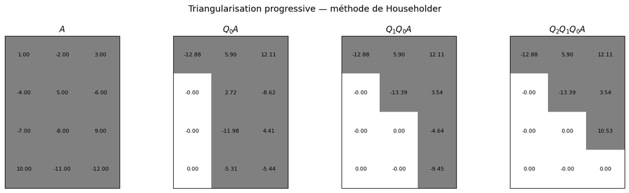

```
Q est-elle orthogonale ?          : True
R est-elle triangulaire supérieure ?: True
```

```python
A = np.array([[ 1.,  -2.,   3.],
              [-4.,   5.,  -6.],
              [-7.,  -8.,   9.],
              [10., -11., -12.]])

def householder_steps(A):
    """Retourne les matrices intermédiaires à chaque étape de Householder."""
    A = A.astype(float)
    m, n = A.shape
    current = A.copy()
    steps = [current.copy()]

    for i in range(n):      #Pratiquement la même chose que pour householder_qr(), mais on n'accumule pour avoir Q, on sauvegarde dans "steps" le produit matriciel à chaque itération
        x = current[i:, i]
        sign = 1.0 if x[0] >= 0 else -1.0
        v = sign * np.linalg.norm(x) * np.eye(len(x), 1).flatten() + x
        if v @ v < 1e-14:
            steps.append(current.copy())
            continue
        H = np.eye(len(x)) - 2 * np.outer(v, v) / (v @ v)
        current[i:, i:] = H @ current[i:, i:]
        steps.append(current.copy())

    return steps

#Graphique présentant la triangularisation progressive
from matplotlib.colors import ListedColormap
cmap = ListedColormap(["white", "gray"]) # ColorMap discrète : soit blanc soit gris, pas de nuance

steps = householder_steps(A)
labels = ["$A$", "$Q_0 A$", "$Q_1 Q_0 A$", "$Q_2 Q_1 Q_0 A$"]

fig, axes = plt.subplots(1, len(steps), figsize=(14, 4))

for ax, mat, label in zip(axes, steps, labels):
    masque = (~np.isclose(mat, 0)).astype(float) #nouvelle matrice ou les valeurs nulles restent 0.0, et les non-nulles deviennet 1.0
    ax.imshow(masque, cmap=cmap, vmin=0, vmax=1) #blanc pour les valeurs nulles, gris pour les valeurs non-nulles
    ax.set_title(label, fontsize=12)
    for r in range(mat.shape[0]):
        for c in range(mat.shape[1]):
            ax.text(c, r, f"{mat[r, c]:.2f}", ha='center', va='center', fontsize=8)
    ax.set_xticks([])
    ax.set_yticks([])

plt.suptitle("Triangularisation progressive — méthode de Householder", fontsize=13)
plt.tight_layout()
plt.show()

# Même vérification qu'à la question c.
Q, R = householder_qr(A)
print("Q est-elle orthogonale ?          :", np.allclose(Q.T @ Q, np.eye(4)))
print("R est-elle triangulaire supérieure ?:", np.allclose(R, np.triu(R)))
```

L'application en chaîne des $Q_i$ sur $A$ triangularise proressivement la matrice $A$. En effet chaque $Q_i$ agit sur le sous espace de la colone $i$ de la matrice $\sum_{j=0}^{i-1}Q_jA$, il transforme cette colone en une colone ou les $m-(i+1)$ derniers éléments sont nuls. Nous obtenons bien à la fin une matrice triangulaire.

✦ ✦ ✦

2

## Mesures imprécises dans un jeu de bataille navale

**Mise en contexte :**

Dans de nombreuses situations expérimentales, les données mesurées sont affectées par du bruit ou des erreurs de mesure. Lorsqu’on tente d’ajuster un modèle mathématique à ces données, on obtient souvent un système linéaire surdéterminé, c’est-à-dire comportant plus d’équations que d’inconnues.

Un tel système peut s’écrire sous la forme

$$ X\alpha = Y, $$

où (X) est une matrice contenant les variables du modèle, (Y) le vecteur des observations expérimentales et ($\alpha$) le vecteur des paramètres à déterminer. En général, ce système n’admet pas de solution exacte.

On cherche alors une solution approchée qui minimise l’erreur quadratique entre les données observées et les valeurs prédites par le modèle :

$$ \min_\alpha \|Y - X\alpha\|_2 . $$

Cette méthode est connue sous le nom de méthode des moindres carrés.

Une façon efficace et numériquement stable de résoudre ce problème consiste à utiliser la décomposition QR de la matrice (X). En écrivant

$$ X = QR, $$

où (Q) est orthogonale et (R) triangulaire supérieure, le problème des moindres carrés se réduit à la résolution d’un système triangulaire plus simple. Nous utilisons donc la décomposition QR afin d’estimer les paramètres d’un modèle décrivant la trajectoire d’un projectile à partir de données expérimentales bruitées.

✦ ✦ ✦

2 a

## Modifiez votre code de décomposition QR pour qu’il retourne la décomposition QR réduite de la matrice d’entrée lorsque l’argument additionnel reduite=True lui est passé.

Il est préférable d’utiliser la décomposition QR réduite de la matrice (X). Si (X) est de dimension $(m \times n)$ avec $(m \ge n)$, alors la forme réduite s’écrit

$$ X = \hat{Q}\hat{R}, $$

où $( \hat{Q} )$ est de dimension $(m \times n$) et $( \hat{R} )$ est triangulaire supérieure de dimension $(n \times n)$.

Nous modifions donc notre fonction `householder_qr` pour qu’elle puisse retourner soit la décomposition complète, soit la décomposition réduite lorsque l’argument `reduite=True` est passé.

```python
def householder_qr(A, reduite=False):
    """
    Décomposition QR d'une matrice A par la méthode de Householder.

    Paramètres
    ----------
    A : np.ndarray
        Matrice de dimension m x n avec m >= n.
    reduite : bool, optionnel
        Si True, retourne la décomposition QR réduite.
        Sinon, retourne la décomposition QR complète.

    Retourne
    --------
    Q, R : tuple de np.ndarray
        - Si reduite=False :
            Q est de dimension m x m
            R est de dimension m x n
        - Si reduite=True :
            Q est de dimension m x n
            R est de dimension n x n
    """
    A = A.astype(float)
    m, n = A.shape

    R = A.copy()
    Q = np.eye(m)

    for i in range(n):
        x = R[i:, i]

        sign = 1.0 if x[0] >= 0 else -1.0
        e1 = np.zeros_like(x)
        e1[0] = 1.0
        v = sign * np.linalg.norm(x) * e1 + x

        # Si la colonne est déjà dans la bonne direction, on passe à la suivante
        if np.linalg.norm(v) < 1e-14:
            continue

        H = np.eye(len(x)) - 2 * np.outer(v, v) / (v @ v)

        # Application de la réflexion à la sous-matrice pertinente
        R[i:, i:] = H @ R[i:, i:]

        # Accumulation pour construire Q^T, puis on transpose à la fin
        Q[i:, :] = H @ Q[i:, :]

    Q = Q.T

    if reduite:
        return Q[:, :n], R[:n, :]
    else:
        return Q, R
```

On peut encore vérifier avec la matrice :
$$ A= \begin{bmatrix} 1 & -2 & 3\\ -4 & 5 & -6\\ -7 & -8 & 9\\ 10 & -11 & -12\\ \end{bmatrix} $$

```python
A = np.array([[1., -2., 3.],
              [-4., 5., -6.],
              [-7., -8., 9.],
              [10., -11., -12.]])

Q_red, R_red = householder_qr(A, reduite=True)

print("Q réduite =\n", np.round(Q_red, 6))
print()
print("R réduite =\n", np.round(R_red, 6))
print()
print("Dimensions de Q réduite :", Q_red.shape)
print("Dimensions de R réduite :", R_red.shape)
print()
print("Est-ce que Q_red @ R_red redonne A ? :", np.allclose(Q_red @ R_red, A))
print("Est-ce que Q_red^T Q_red = I ? :", np.allclose(Q_red.T @ Q_red, np.eye(A.shape[1])))
print("Est-ce que R_red est triangulaire supérieure ? :", np.allclose(R_red, np.triu(R_red)))
```

```
Q réduite =
 [[-0.077615  0.115201  0.33544 ]
 [ 0.31046  -0.236702 -0.847277]
 [ 0.543305  0.837009 -0.051609]
 [-0.776151  0.479705 -0.408581]]

R réduite =
 [[-12.884099   5.898744  12.107948]
 [ -0.       -13.38674    3.542437]
 [ -0.         0.        10.528472]]

Dimensions de Q réduite : (4, 3)
Dimensions de R réduite : (3, 3)

Est-ce que Q_red @ R_red redonne A ? : True
Est-ce que Q_red^T Q_red = I ? : True
Est-ce que R_red est triangulaire supérieure ? : True
```

Les tests effectués confirment que l’implémentation de la décomposition QR réduite est correcte. En effet, on observe que la multiplication $( Q_{\text{red}} R_{\text{red}} )$ reconstruit bel et bien la matrice originale $(A)$, ce qui valide la factorisation obtenue.

Aussi, la condition $( Q_{\text{red}}^T Q_{\text{red}} = I )$ est satisfaite, ce qui confirme que les colonnes de $(Q_{\text{red}})$ sont orthonormales. La matrice $(R_{\text{red}})$ est triangulaire supérieure, comme attendu pour une décomposition QR.

Ainsi la décomposition QR réduite pourra donc être utilisée pour résoudre les problèmes de moindres carrés dans les sections suivantes.

✦ ✦ ✦

2 b

## Utilisez votre code pour résoudre approximativement l’équation (3.9). Vous utiliserez les données fournies dans le fichier bataille_navale_equipe0XX.csv où vous remplacerez 0XX par votre numéro d’équipe dans la boîte dépôt sur MonPortail.

(Nous sommes l'équipe 43)

À partir des données expérimentales $(x_i, y_i)$ fournies dans le fichier `bataille_navale_equipe043.csv`, on construit le système surdéterminé.

$$ X\alpha = Y, $$

avec

$$ X = \begin{pmatrix} 1 & x_1 & x_1^2 \\ 1 & x_2 & x_2^2 \\ \vdots & \vdots & \vdots \\ 1 & x_n & x_n^2 \end{pmatrix}, \qquad \alpha = \begin{pmatrix} \alpha_0 \\ \alpha_1 \\ \alpha_2 \end{pmatrix}, \qquad Y = \begin{pmatrix} y_1 \\ y_2 \\ \vdots \\ y_n \end{pmatrix}. $$

Comme les données sont bruitées, ce système n’admet généralement pas de solution exacte. On cherche donc la solution des moindres carrés, c’est-à-dire celle qui minimise

$$ \|Y - X\alpha\|_2. $$

En utilisant la décomposition QR réduite de (X),

$$ X = \hat Q \hat R, $$

on obtient le système triangulaire supérieur

$$ \hat R \alpha = \hat Q^T Y, $$

qui peut ensuite être résolu par rétrosubstitution.

```python
import numpy as np
import pandas as pd
from IPython.display import display

def retrosubstitution(R, b):
    """
    Résout le système triangulaire supérieur Rx = b
    par rétrosubstitution.
    """
    n = len(b)
    x = np.zeros(n)

    for i in range(n - 1, -1, -1):
        x[i] = (b[i] - np.dot(R[i, i+1:], x[i+1:])) / R[i, i]

    return x

# Chargement des données de l'équipe 43
df = pd.read_csv("bataille_navale_equipe043.csv")

print("Aperçu des données :")
display(df)

# Extraction des colonnes
x = df["x"].to_numpy(dtype=float)
y = df["y"].to_numpy(dtype=float)

# Construction de la matrice X et du vecteur Y
X = np.column_stack((np.ones_like(x), x, x**2))
Y = y.copy()

print("Matrice X =")
print(X)
print()
print("Vecteur Y =")
print(Y)

# Décomposition QR réduite
Q_red, R_red = householder_qr(X, reduite=True)

# Résolution du système R_hat alpha = Q_hat^T Y
b = Q_red.T @ Y
alpha = retrosubstitution(R_red, b)

print("\nParamètres estimés :")
print(f"alpha_0 = {alpha[0]:.8f}")
print(f"alpha_1 = {alpha[1]:.8f}")
print(f"alpha_2 = {alpha[2]:.8f}")

# Vérifications
print("\nVérifications :")
print("Dimensions de Q_red :", Q_red.shape)
print("Dimensions de R_red :", R_red.shape)
print("Est-ce que X ≈ Q_red @ R_red ? :", np.allclose(X, Q_red @ R_red))
print("Est-ce que Q_red^T Q_red = I ? :", np.allclose(Q_red.T @ Q_red, np.eye(X.shape[1])))
print("Est-ce que R_red est triangulaire supérieure ? :", np.allclose(R_red, np.triu(R_red)))

# Résidu
residu = np.linalg.norm(Y - X @ alpha)
print(f"Norme du résidu ||Y - X alpha||_2 = {residu:.8e}")
```

```
Aperçu des données :
```

|  | x | y |
| --- | --- | --- |
| 0 | 2635.044833 | 10.858444 |
| 1 | 2564.263586 | 161.076163 |
| 2 | 2493.580280 | 308.004630 |
| 3 | 2422.851150 | 443.438529 |
| 4 | 2352.127261 | 565.146413 |
| 5 | 2281.425026 | 683.029045 |
| 6 | 2210.720744 | 794.959441 |
| 7 | 2139.977697 | 884.020876 |

```
Matrice X =
[[1.00000000e+00 2.63504483e+03 6.94346127e+06]
 [1.00000000e+00 2.56426359e+03 6.57544774e+06]
 [1.00000000e+00 2.49358028e+03 6.21794261e+06]
 [1.00000000e+00 2.42285115e+03 5.87020769e+06]
 [1.00000000e+00 2.35212726e+03 5.53250265e+06]
 [1.00000000e+00 2.28142503e+03 5.20490015e+06]
 [1.00000000e+00 2.21072074e+03 4.88728621e+06]
 [1.00000000e+00 2.13997770e+03 4.57950454e+06]]

Vecteur Y =
[ 10.85844404 161.07616314 308.00462961 443.43852869 565.14641276
 683.02904465 794.95944124 884.02087625]

Paramètres estimés :
alpha_0 = -658.13243136
alpha_1 = 2.74765634
alpha_2 = -0.00094659

Vérifications :
Dimensions de Q_red : (8, 3)
Dimensions de R_red : (3, 3)
Est-ce que X ≈ Q_red @ R_red ? : True
Est-ce que Q_red^T Q_red = I ? : True
Est-ce que R_red est triangulaire supérieure ? : True
Norme du résidu ||Y - X alpha||_2 = 6.98833148e+00
```

### Paramètres estimés de $(\alpha_0)$, $(\alpha_1)$ et $(\alpha_2)$

$\alpha_0 = -658.13243136$

$\alpha_1 = 2.74765634 $

$\alpha_2 = -0.00094659 $

### Interpretation

Les paramètres estimés permettent de reconstruire la trajectoire du projectile à l’aide du modèle quadratique

$ y(x) = α₀ + α₁ x + α₂ x² $

- Le coefficient α₀ représente l’ordonnée à l’origine, c’est-à-dire la hauteur initiale du projectile lorsque x = 0.
- Le coefficient α₁ correspond à la pente initiale de la trajectoire et est lié à la direction de lancement du projectile.
- Le coefficient α₂ est négatif, ce qui indique que la trajectoire est une parabole ouverte vers le bas, comme attendu pour un mouvement soumis à la gravité.

Ces valeurs permettent donc de modéliser correctement la trajectoire observée. La norme du résidu ||Y − Xα||₂ obtenue est relativement faible, ce qui indique que le modèle quadratique ajuste bien les données expérimentales.

### Conclusion

Nous avons ainsi construit le système surdéterminé associé au modèle quadratique de la trajectoire. En appliquant la décomposition QR réduite à la matrice $(X)$, nous avons transformé le problème des moindres carrés en un système triangulaire supérieur, ensuite résolu par rétrosubstitution.

Les paramètres $(\alpha_0)$, $(\alpha_1)$ et $(\alpha_2)$ obtenus définissent ainsi la trajectoire quadratique estimée du projectile.

✦ ✦ ✦

2 c

## Tracez les données (cercles noirs) et la solution estimée de la trajectoire (ligne pleine de la couleur de votre choix) donnée par l’équation (3.8).

Nous voulons tracés les données expérimentales $(x_i,y_i)$ sous forme de cercles noirs, puis la courbe ajustée obtenue à partir des paramètres estimés du modèle quadratique

$$ y(x)=\alpha_0+\alpha_1x+\alpha_2x^2. $$

Ce graphique permet de visualiser la qualité de l’ajustement et de vérifier si le modèle reproduit correctement la trajectoire observée du projectile.

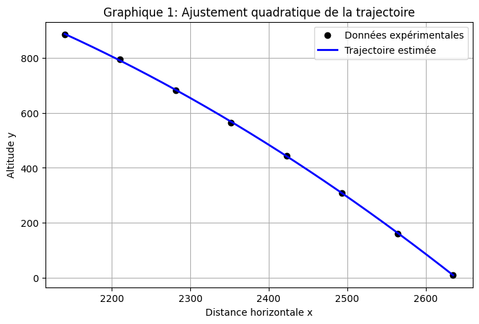

```python
import numpy as np
import matplotlib.pyplot as plt

# Paramètres estimés
alpha_0 = -658.13243136
alpha_1 = 2.74765634
alpha_2 = -0.00094659

# Domaine pour tracer la courbe
x_modele = np.linspace(np.min(x), np.max(x), 500)
y_modele = alpha_0 + alpha_1*x_modele + alpha_2*x_modele**2

# Graphique
plt.figure(figsize=(8,5))

plt.plot(x, y, 'ko', label='Données expérimentales')
plt.plot(x_modele, y_modele, 'b-', linewidth=2, label='Trajectoire estimée')

plt.title("Graphique 1: Ajustement quadratique de la trajectoire")
plt.xlabel("Distance horizontale x")
plt.ylabel("Altitude y")

plt.legend()
plt.grid(True)

plt.show()
```

✦ ✦ ✦

2 d

## Obtenez la position d’impact du projectile (à y = 0) en résolvant l’équation quadratique (3.8) pour x à l’aide d’une implémentation personnelle de la méthode de la bissection. Comparez votre solution avec celle obtenue en résolvant cette même équation analytiquement. Considérant que votre embarcation se situe à la position (x, y) = (0, 0), quelle est la distance horizontale vous séparant du point d’impact ?

Pour déterminer la position d’impact du projectile, on cherche la valeur de (x) telle que

$$ y(x)=\alpha_0+\alpha_1x+\alpha_2x^2 = 0. $$

La position d’impact correspond donc à la valeur de $(x)$ pour laquelle la trajectoire coupe l’axe horizontal, c’est-à-dire lorsque $y(x)=0$. La résolution de l’équation quadratique donne deux racines. La racine pertinente physiquement est la plus grande, puisqu’elle correspond au moment où le projectile atteint l’eau après avoir traversé les points mesurés. Pour resolver cette équation on utlise la méthode de la bissection et la resolver analytiquement.

La trajectoire quadratique coupe l’axe $y=0$ en deux points. La première intersection correspond à une racine située avant les données expérimentales, tandis que la seconde correspond à la position d’impact du projectile. La distance horizontale entre l’embarcation et le point d’impact est donc donnée par la plus grande racine.

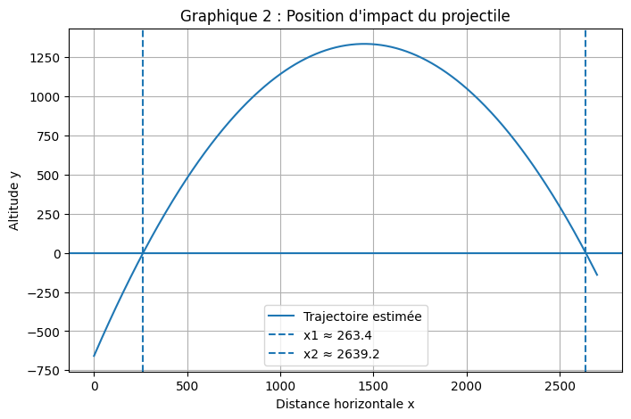

```python
import numpy as np
import matplotlib.pyplot as plt

# paramètres trouvés au 2b)
alpha_0 = -658.13243136
alpha_1 = 2.74765634
alpha_2 = -0.00094659

# racines
x1 = 263.433
x2 = 2639.246

# domaine pour tracer la parabole
x_plot = np.linspace(0, 2700, 500)
y_plot = alpha_0 + alpha_1*x_plot + alpha_2*x_plot**2

plt.figure(figsize=(8,5))

# parabole
plt.plot(x_plot, y_plot, label="Trajectoire estimée")

# ligne y=0 (surface de l'eau)
plt.axhline(0)

# racines
plt.axvline(x1, linestyle="--", label=f"x1 ≈ {x1:.1f}")
plt.axvline(x2, linestyle="--", label=f"x2 ≈ {x2:.1f}")

plt.xlabel("Distance horizontale x")
plt.ylabel("Altitude y")
plt.title("Graphique 2 : Position d'impact du projectile")
plt.legend()
plt.grid()

plt.show()
```

```python
import numpy as np

#méthode de la bissection
# Paramètres obtenus au 2b)
alpha_0 = -658.13243136
alpha_1 = 2.74765634
alpha_2 = -0.00094659

def f(x):
    return alpha_0 + alpha_1*x + alpha_2*x**2

def bissection(f, a, b, tol=1e-10, max_iter=1000):
    """
    Trouve une racine de f dans [a,b] par la méthode de la bissection.
    On suppose que f(a) et f(b) sont de signes opposés.
    """
    fa = f(a)
    fb = f(b)

    if fa * fb > 0:
        raise ValueError("La bissection exige un changement de signe sur [a,b].")

    for _ in range(max_iter):
        c = (a + b) / 2
        fc = f(c)

        if abs(fc) < tol or (b - a)/2 < tol:
            return c

        if fa * fc < 0:
            b = c
            fb = fc
        else:
            a = c
            fa = fc

    return (a + b) / 2
```

```python
# Choix d'un intervalle contenant la racine physique
# On cherche la plus grande racine, donc l'impact à droite des points mesurés
a = 2635
b = 2650

x_impact_bis = bissection(f, a, b)

print(f"Racine obtenue par bissection : x = {x_impact_bis:.12f}")
print(f"f(x_impact_bis) = {f(x_impact_bis):.12e}")
```

```
Racine obtenue par bissection : x = 2639.256164691687
f(x_impact_bis) = 4.092726157978e-11
```

```python
# Solution analytique
delta = alpha_1**2 - 4*alpha_2*alpha_0

x1 = (-alpha_1 + np.sqrt(delta)) / (2*alpha_2)
x2 = (-alpha_1 - np.sqrt(delta)) / (2*alpha_2)

print(f"Racines analytiques : x1 = {x1:.12f}, x2 = {x2:.12f}")

# On garde la plus grande racine, qui correspond à la position d'impact
x_impact_analytique = max(x1, x2)

print(f"Position d'impact (solution analytique) : x = {x_impact_analytique:.12f}")
print(f"Distance horizontale entre l'embarcation et le point d'impact : {x_impact_analytique:.6f}")
```

```
Racines analytiques : x1 = 263.432792512575, x2 = 2639.256164691705
Position d'impact (solution analytique) : x = 2639.256164691705
Distance horizontale entre l'embarcation et le point d'impact : 2639.256165
```

### Résultats et comparaison

Les deux méthodes donnent des résultats en excellent accord :

| Méthode | $x_{\text{impact}}$ |
| --- | --- |
| Bissection | $\approx 2639.256164691687$ |
| Analytique | $\approx 2639.256164691705$ |
| Écart absolu | $\approx 1.8 \times 10^{-11}$ |

L'écart entre les deux méthodes est inférieur à la tolérance $\varepsilon = 10^{-10}$ imposée à la bissection, ce qui confirme la convergence de la méthode numérique vers la solution exacte. L'erreur théorique maximale après $n$ itérations est $(b-a)/2^n$, ce qui permet d'estimer a priori le nombre d'itérations nécessaire pour atteindre une précision donnée.

La trajectoire quadratique coupe l'axe $y=0$ en deux points :

- $x_1 \approx 263.43$ : racine rejetée (avant les données expérimentales)
- $x_2 \approx 2639.26$ : position d'impact physique

Comme l'embarcation est à l'origine $(0, 0)$, la distance horizontale nous séparant du point d'impact est : $$d \approx 2639.256 \text{ m}$$

✦ ✦ ✦

3

## Modèle épidemiologique SIR sur réseau

**Mise en contexte :** Le modèle SIR (Susceptible–Infecté–Rétabli) est un modèle épidémiologique classique utilisé pour décrire la propagation d’une maladie contagieuse au sein d’une population. Dans ce cadre, chaque individu peut se trouver dans l’un des trois états suivants : susceptible (S), infecté (I) ou rétabli (R). Un individu susceptible peut devenir infecté après un contact avec une personne contagieuse, puis finit par se rétablir et devient immunisé.

Dans ce problème, on considère un modèle SIR sur réseau où chaque individu peut entrer en contact avec un certain nombre de voisins. Le nombre de contacts est modélisé par une distribution géométrique de moyenne $ \kappa = 5 $. On suppose également qu’un individu infecté transmet la maladie à chacun de ses voisins indépendamment avec une probabilité de transmission $ T $.

Un indicateur important de la propagation de la maladie est la fraction finale d’individus infectés au cours de l’épidémie, notée $ R_\infty $. Cette quantité dépend d’une variable intermédiaire $ u $, définie comme la plus petite solution non négative d’une équation non linéaire. Dans ce modèle, cette variable satisfait une équation cubique qui doit être résolue pour déterminer le comportement du système.

L’objectif de cette question est donc d’étudier cette équation non linéaire associée au modèle SIR, d’en trouver les solutions analytiques et d’en analyser les implications pour la propagation de l’épidémie.

On cherche toutes les solutions de

$$ u=\frac{1}{[1+4T(1-u)]^2}. $$

#### (1) Mettre l’équation sous forme polynomiale

On multiplie des deux côtés par $[1+4T(1-u)]^2$ :

$$ u[1+4T(1-u)]^2=1. $$

Développons d’abord le terme entre crochets :

$$ 1+4T(1-u)=1+4T-4Tu. $$

Donc

$$ u(1+4T-4Tu)^2=1. $$

En développant :

$$ u\left[(1+4T)^2-8T(1+4T)u+16T^2u^2\right]=1. $$

Ainsi,

$$ 16T^2u^3-(8T+32T^2)u^2+(1+8T+16T^2)u-1=0. $$

#### (2) Factoriser le polynôme

On remarque immédiatement que (u=1) est une solution, car

$$ \frac{1}{[1+4T(1-1)]^2}=\frac{1}{1^2}=1. $$

Donc ((u-1)) est un facteur. On factorise :

$$ 16T^2u^3-(8T+32T^2)u^2+(1+8T+16T^2)u-1 = (u-1)\left(16T^2u^2-(16T^2+8T)u+1\right). $$

Il reste donc à résoudre l’équation quadratique

$$ 16T^2u^2-(16T^2+8T)u+1=0. $$

#### (3) Résoudre l’équation quadratique

Ici,

$$ a=16T^2,\qquad b=-(16T^2+8T),\qquad c=1. $$

Par la formule quadratique :

$$ u=\frac{-b\pm\sqrt{b^2-4ac}}{2a}. $$

Donc

$$ u=\frac{16T^2+8T\pm\sqrt{(16T^2+8T)^2-64T^2}}{32T^2}. $$

Calculons le discriminant :

$$ (16T^2+8T)^2-64T^2 =64T^2(2T+1)^2-64T^2 =64T^2\left[(2T+1)^2-1\right]. $$

Or,

$$ (2T+1)^2-1=4T^2+4T=4T(T+1). $$

Donc

$$ \Delta=64T^2\cdot 4T(T+1)=256T^3(T+1). $$

Ainsi,

$$ \sqrt{\Delta}=16\sqrt{T^3(T+1)}. $$

On obtient alors

$$ u=\frac{16T^2+8T\pm16\sqrt{T^3(T+1)}}{32T^2}. $$

En simplifiant :

$$ u=\frac{2T+1\pm2\sqrt{T(T+1)}}{4T}. $$

#### (4) Toutes les solutions

Pour $T>0$, les trois solutions analytiques sont donc

$$ u_1=1, $$

$$ u_2=\frac{2T+1+2\sqrt{T(T+1)}}{4T}, $$

$$ u_3=\frac{2T+1-2\sqrt{T(T+1)}}{4T}. $$

On peut aussi écrire les deux dernières sous la forme

$$ u_{2,3}=\frac{1+2T\pm2\sqrt{T(T+1)}}{4T}. $$

#### (5) Cas particulier (T=0)

Si $T=0$, l’équation originale devient simplement

$$ u=\frac{1}{1^2}=1, $$

donc l’unique solution est

$$ u=1. $$

### Résumé

Les solutions analytiques de l’équation cubique sont

$$ u=1 \quad\text{et}\quad u=\frac{1+2T\pm2\sqrt{T(T+1)}}{4T} \qquad (T>0), $$

avec le cas particulier $T=0\Rightarrow u=1$.

```python
import sympy as sp
import numpy as np

u, T = sp.symbols('u T', real=True)
kappa = 5
c = T * (kappa - 1)  # = 4T

# Équation cubique : u*[1 + c*(1-u)]^2 - 1 = 0
eq = sp.expand(u * (1 + c*(1 - u))**2 - 1)
print("Équation cubique développée (= 0) :")
print(" ", eq)
print()

# Factorisation par (u - 1)
quotient, remainder = sp.div(sp.Poly(eq, u), sp.Poly(u - 1, u), u)
print("Factorisation : (u - 1) × Q(u) + reste")
print("  Reste :", remainder)  # doit être 0
print("  Q(u)  :", quotient.as_expr())
print()

# Racines du quadratique Q(u)
quad = quotient.as_expr()
racines_quad = sp.solve(quad, u)
print("Racines du facteur quadratique :")
for r in racines_quad:
    print(" ", sp.simplify(r))
print()

# Discriminant
a2, b2, c2 = [sp.Poly(quad, u).nth(k) for k in [2, 1, 0]]
discriminant = sp.factor(b2**2 - 4*a2*c2)
print("Discriminant Δ :", discriminant)
print()

# Résumé des 3 racines
print("=" * 50)
print("Les trois solutions de l'équation cubique :")
print("  u₁ = 1")
u_plus  = sp.Rational(1,4) * ((1 + 2*T) + 2*sp.sqrt(T*(T+1))) / T
u_minus = sp.Rational(1,4) * ((1 + 2*T) - 2*sp.sqrt(T*(T+1))) / T
print("  u₊ =", sp.simplify(racines_quad[1]))
print("  u₋ =", sp.simplify(racines_quad[0]))
```

```
Équation cubique développée (= 0) :
  16*T**2*u**3 - 32*T**2*u**2 + 16*T**2*u - 8*T*u**2 + 8*T*u + u - 1

Factorisation : (u - 1) × Q(u) + reste
  Reste : Poly(0, u, domain='ZZ[T]')
  Q(u)  : 16*T**2*u**2 + u*(-16*T**2 - 8*T) + 1

Racines du facteur quadratique :
  (T*(2*T + 1) - 2*sqrt(T**3*(T + 1)))/(4*T**2)
  (T*(2*T + 1) + 2*sqrt(T**3*(T + 1)))/(4*T**2)

Discriminant Δ : 256*T**3*(T + 1)

==================================================
Les trois solutions de l'équation cubique :
  u₁ = 1
  u₊ = (T*(2*T + 1) + 2*sqrt(T**3*(T + 1)))/(4*T**2)
  u₋ = (T*(2*T + 1) - 2*sqrt(T**3*(T + 1)))/(4*T**2)
```

Le calcul symbolique avec `sympy` confirme la forme développée de l’équation cubique, sa factorisation par $(u-1)$ ainsi que les deux autres solutions analytiques du facteur quadratique.

✦ ✦ ✦

3 b

## Démontrez laquelle des solutions obtenues précédemment (ou une combinaison de celles-ci) correspond à u, soit la solution recherchée de l’équation (3.14).

**Identification de la plus petite solution non négative**

À la question 3a), nous avons trouvé les trois solutions de l’équation cubique :

$$ u_1 = 1, $$

$$ u_2 = \frac{1+2T+2\sqrt{T(T+1)}}{4T}, $$

$$ u_3 = \frac{1+2T-2\sqrt{T(T+1)}}{4T}, \qquad (T>0). $$

Nous devons maintenant identifier laquelle correspond à la plus petite solution non négative.

#### (1) Étude de $u_2$

On remarque que

$$ u_2 = \frac{1+2T+2\sqrt{T(T+1)}}{4T}. $$

Comme $T>0$ et $\sqrt{T(T+1)}>T$, on a

$$ 1+2T+2\sqrt{T(T+1)} > 1+4T. $$

Donc

$$ u_2 > \frac{1+4T}{4T} = 1 + \frac{1}{4T} > 1. $$

Ainsi, $u_2$ est toujours strictement supérieure à $1$, donc ce n’est jamais la plus petite solution non négative.

#### (2) Étude de $u_3$

On considère maintenant

$$ u_3 = \frac{1+2T-2\sqrt{T(T+1)}}{4T}. $$

Le numérateur peut s’écrire

$$ 1+2T-2\sqrt{T(T+1)} = (\sqrt{T+1}-\sqrt{T})^2 > 0, $$

donc

$$ u_3 > 0. $$

Il reste à comparer $u_3$ avec $1$.

On cherche quand $u_3 = 1$ :

$$ \frac{1+2T-2\sqrt{T(T+1)}}{4T} = 1. $$

En multipliant par $4T$,

$$ 1+2T-2\sqrt{T(T+1)} = 4T. $$

Donc

$$ 1-2T = 2\sqrt{T(T+1)}. $$

En élevant au carré,

$$ (1-2T)^2 = 4T(T+1). $$

Développons :

$$ 1 - 4T + 4T^2 = 4T^2 + 4T. $$

Ainsi,

$$ 1 = 8T, $$

soit

$$ T_c = \frac{1}{8}. $$

#### (3) Comparaison selon la valeur de $T$

- Si $0 < T < \dfrac18$, alors $u_3 > 1$, donc la plus petite solution non négative est

$$ u = 1. $$

- Si $T = \dfrac18$, alors

$$ u_3 = 1, $$

donc les deux solutions coïncident et

$$ u = 1. $$

- Si $\dfrac18 < T \le 1$, alors $u_3 < 1$, donc la plus petite solution non négative est

$$ u = \frac{1+2T-2\sqrt{T(T+1)}}{4T}. $$

#### (4) Cas (T=0)

Lorsque $T=0$, l’équation originale devient

$$ u=1, $$

donc

$$ u=1. $$

### Conclusion

La plus petite solution non négative est donc

$$ u(T)= \begin{cases} 1, & 0 \le T \le \dfrac18, \\[8pt] \dfrac{1+2T-2\sqrt{T(T+1)}}{4T}, & \dfrac18 < T \le 1. \end{cases} $$

Le seuil critique séparant les deux comportements est donc

$$ T_c = \frac18. $$

```
Vérification : u = f(u) pour chaque racine
=======================================================
T = 0.050:
  u1=1   → f(1)   = 1.000000  (résidu = 0.00e+00)
  u-=3.2087 → f(u-) = 3.208712  (résidu = 4.44e-16)
  u+=7.7913 → f(u+) = 7.791288  (résidu = 1.33e-14)
T = 0.125:
  u1=1   → f(1)   = 1.000000  (résidu = 0.00e+00)
  u-=1.0000 → f(u-) = 1.000000  (résidu = 0.00e+00)
  u+=4.0000 → f(u+) = 4.000000  (résidu = 0.00e+00)
T = 0.300:
  u1=1   → f(1)   = 1.000000  (résidu = 0.00e+00)
  u-=0.2925 → f(u-) = 0.292500  (résidu = 5.55e-17)
  u+=2.3742 → f(u+) = 2.374166  (résidu = 3.11e-15)
T = 0.700:
  u1=1   → f(1)   = 1.000000  (résidu = 0.00e+00)
  u-=0.0779 → f(u-) = 0.077949  (résidu = 4.16e-17)
  u+=1.6363 → f(u+) = 1.636337  (résidu = 2.22e-16)
T = 1.000:
  u1=1   → f(1)   = 1.000000  (résidu = 0.00e+00)
  u-=0.0429 → f(u-) = 0.042893  (résidu = 4.86e-17)
  u+=1.4571 → f(u+) = 1.457107  (résidu = 8.88e-16)
```

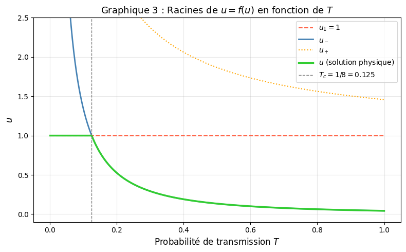

```
Seuil critique : T_c = 1/8 = 0.125
Pour T < T_c : u = 1 (pas d'épidémie)
Pour T > T_c : u = u_- ∈ (0, 1) (épidémie)
```

```python
import numpy as np
import matplotlib.pyplot as plt

kappa = 5

def u_minus(T):
    """Plus petite racine du facteur quadratique."""
    return ((1 + 2*T) - 2*np.sqrt(T*(T + 1))) / (4*T)

def u_plus(T):
    """Plus grande racine du facteur quadratique."""
    return ((1 + 2*T) + 2*np.sqrt(T*(T + 1))) / (4*T)

def f(u, T):
    """Fonction f(u) = 1 / [1 + T*(kappa-1)*(1-u)]^2."""
    return 1 / (1 + T*(kappa - 1)*(1 - u))**2

# Vérification numérique : les trois racines satisfont bien u = f(u)
print("Vérification : u = f(u) pour chaque racine")
print("=" * 55)
T_c = 1/8
for T_val in [0.05, T_c, 0.3, 0.7, 1.0]:
    um = u_minus(T_val) if T_val > 0 else 1.0
    up = u_plus(T_val)  if T_val > 0 else 1.0
    print(f"T = {T_val:.3f}:")
    print(f"  u1=1   → f(1)   = {f(1.0, T_val):.6f}  (résidu = {abs(1 - f(1.0, T_val)):.2e})")
    print(f"  u-={um:.4f} → f(u-) = {f(um, T_val):.6f}  (résidu = {abs(um - f(um, T_val)):.2e})")
    print(f"  u+={up:.4f} → f(u+) = {f(up, T_val):.6f}  (résidu = {abs(up - f(up, T_val)):.2e})")
print()

# Identifier u (plus petite solution non négative) selon T
T_vals = np.linspace(1e-3, 1.0, 500)
u_sol = np.where(T_vals >= T_c, u_minus(T_vals), 1.0)

# Graphique : les trois racines en fonction de T
fig, ax = plt.subplots(figsize=(8, 5))

ax.plot(T_vals, np.ones_like(T_vals), color='tomato',    lw=1.5, ls='--', label=r'$u_1 = 1$')
ax.plot(T_vals, u_minus(T_vals),      color='steelblue', lw=2,   label=r'$u_-$')
ax.plot(T_vals, u_plus(T_vals),       color='orange',    lw=1.5, ls=':', label=r'$u_+$')
ax.plot(T_vals, u_sol,                color='limegreen', lw=2.5, ls='-', label=r'$u$ (solution physique)')

ax.axvline(T_c, color='gray', ls='--', lw=1, label=f'$T_c = 1/8 = {T_c}$')
ax.set_xlabel(r'Probabilité de transmission $T$', fontsize=12)
ax.set_ylabel(r'$u$', fontsize=12)
ax.set_title(r'Graphique 3 : Racines de $u = f(u)$ en fonction de $T$', fontsize=13)
ax.set_ylim(-0.1, 2.5)
ax.legend(fontsize=10)
ax.grid(True, alpha=0.3)
plt.tight_layout()
plt.show()

print(f"Seuil critique : T_c = 1/8 = {T_c}")
print(f"Pour T < T_c : u = 1 (pas d'épidémie)")
print(f"Pour T > T_c : u = u_- ∈ (0, 1) (épidémie)")
```

Le graphique 3 illustre les différentes solutions de l’équation $u = f(u)$ en fonction de la probabilité de transmission $T$. Les trois courbes correspondent aux trois racines analytiques trouvées précédemment : $u_1 = 1$, $u_-$ et $u_+$.

La ligne horizontale rouge représente la solution constante $u_1 = 1$. Les deux autres courbes correspondent aux solutions issues du facteur quadratique de l’équation cubique. Cependant, toutes ces solutions ne sont pas physiquement pertinentes.

La solution physique correspond à la plus petite solution non négative, représentée en vert. On observe que pour $T \leq T_c = 1/8$, la solution physique reste $u = 1$. Cela signifie que l’infection ne se propage pas à grande échelle dans la population.

Lorsque $T > T_c$, la solution physique bascule vers la branche $u_-$, qui diminue progressivement lorsque $T$ augmente. Cela correspond à l’apparition d’une épidémie touchant une fraction non nulle de la population.

La ligne verticale pointillée indique le seuil épidémique critique $T_c = 1/8$, qui sépare le régime sans propagation globale de la maladie du régime où l’épidémie peut se développer dans le réseau.

✦ ✦ ✦

3 c

## Tracez R∞ en fonction de T et identifiez tout changement qualitatif de R∞. Comment interprétez-vous ce changement (ou cette absence de changement) ?

On veut tracer la fraction finale d’individus infectés,

$$ R_\infty = 1-\frac{1-T(1-u)}{1+4T(1-u)}, $$

où (u) est la plus petite solution non négative de l’équation (3.14).  
D’après la question précédente, la solution physique est

$$ u(T)= \begin{cases} 1, & 0\le T \le \dfrac18,\\[6pt] \dfrac{1+2T-2\sqrt{T(T+1)}}{4T}, & \dfrac18 < T \le 1. \end{cases} $$

Nous pouvons donc calculer $R_\infty(T)$ analytiquement sur tout l’intervalle $0\le T\le 1$.

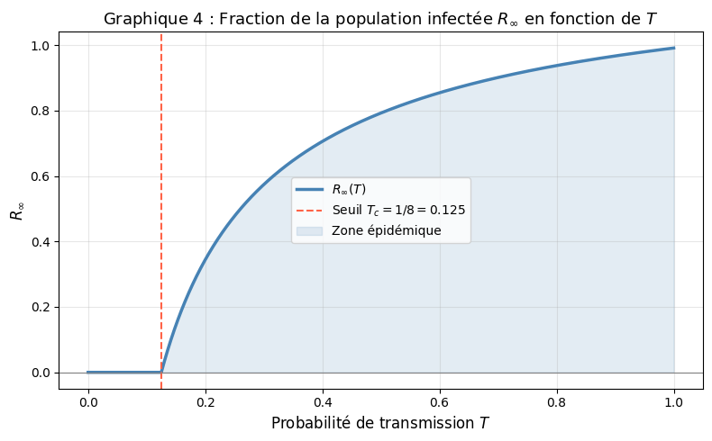

```
Seuil épidémique : T_c = 1/8 = 0.125
R_inf(T=0.1)  = 0.000000  (< T_c, pas d'épidémie)
R_inf(T=0.5)  = 0.792468
R_inf(T=1.0)  = 0.991117
```

```python
import numpy as np
import matplotlib.pyplot as plt

kappa = 5
T_c   = 1/8

def u_minus(T):
    return ((1 + 2*T) - 2*np.sqrt(T*(T + 1))) / (4*T)

def R_inf(T):
    u   = np.where(T > T_c, u_minus(T), 1.0)
    num = 1 - T*(1 - u)
    den = 1 + T*(kappa - 1)*(1 - u)
    return 1 - num / den

T_vals = np.linspace(1e-6, 1.0, 2000)
R_vals = R_inf(T_vals)

fig, ax = plt.subplots(figsize=(8, 5))
ax.plot(T_vals, R_vals, color='steelblue', lw=2.5, label=r'$R_\infty(T)$')
ax.axvline(T_c, color='tomato', ls='--', lw=1.5, label=f'Seuil $T_c = 1/8 = {T_c}$')
ax.axhline(0,   color='gray',   ls='-',  lw=0.8)
ax.fill_between(T_vals, 0, R_vals, where=(T_vals > T_c),
                alpha=0.15, color='steelblue', label='Zone épidémique')
ax.set_xlabel(r'Probabilité de transmission $T$', fontsize=12)
ax.set_ylabel(r'$R_\infty$', fontsize=12)
ax.set_title(r'Graphique 4 : Fraction de la population infectée $R_\infty$ en fonction de $T$', fontsize=13)
ax.legend(fontsize=10)
ax.grid(True, alpha=0.3)
plt.tight_layout()
plt.show()

print(f"Seuil épidémique : T_c = 1/8 = {T_c}")
print(f"R_inf(T=0.1)  = {R_inf(0.1):.6f}  (< T_c, pas d'épidémie)")
print(f"R_inf(T=0.5)  = {R_inf(0.5):.6f}")
print(f"R_inf(T=1.0)  = {R_inf(1.0):.6f}")
```

### Analyse du graphique

Le graphique montre un changement qualitatif clair au seuil

$$ T_c = \frac18 = 0.125. $$

Pour

$$ 0 \le T \le \frac18, $$

on obtient

$$ u=1, $$

et donc

$$ R_\infty = 0. $$

Cela signifie qu’aucune fraction macroscopique de la population n’est infectée : l’infection ne se propage pas à grande échelle dans le réseau.

En revanche, pour

$$ T > \frac18, $$

la solution physique devient

$$ u=\frac{1+2T-2\sqrt{T(T+1)}}{4T} < 1, $$

ce qui donne

$$ R_\infty > 0. $$

La fraction finale infectée devient alors non nulle et croît avec (T). Plus la probabilité de transmission est grande, plus l’épidémie touche une grande partie de la population.

Le changement qualitatif observé correspond à l’apparition d’un seuil épidémique.  
Sous ce seuil, la transmissibilité est trop faible pour soutenir une propagation importante de la maladie dans le réseau. Au-dessus de ce seuil, la maladie peut se transmettre de proche en proche à une fraction finie de la population.

On observe donc une transition entre deux régimes :

1. **Régime sous-critique** : $R_\infty = 0$, pas d’épidémie à grande échelle ;
2. **Régime supercritique** : $R_\infty > 0$, apparition d’une épidémie touchant une fraction non nulle de la population.

✦ ✦ ✦

3 d

## Résolvez numériquement l’équation (3.14) à l’aide d’implémentations personnelles de la méthode par relaxation et de la méthode de Newton-Raphson pour 20 valeurs de T uniformément distribuées dans l’intervalle [0, 1]. Illustrez vos résultats à l’aide d’un graphique comparant les solutions analytiques (indiquées avec des lignes de couleurs distinctes) aux solutions numériques obtenues avec différentes valeurs initiales de l’algorithme (symboles ; choisissez bien vos symboles pour que vos solutions soient bien visibles). Arrivez-vous à obtenir les trois solutions identifiées en a ? Pourquoi ? Considérez tracer l’équation (3.14) de même que la dérivée de f(u) en fonction de u et ce, pour quelques valeurs de T, pour appuyer vos conclusions. Vous pouvez aussi tracer les itérations successives de chacune des méthodes afin d’illustrer la manière dont elles convergent vers l’une ou l’autre des solutions (ex. : tracer un diagramme en toile d’araignée).

Commençons par implémenter les méthodes de relaxation et de Newton-Raphson, pour résoudre $(3.14)$, pour 20 valeurs de $T$ uniformément distribuées dans $[0,1]$ et 3 différentes valeurs de $u_0$, $u_0\in \{ 0 \,\,;\, 0,5 \,\,;\, 0,99 \}$

```python
kappa = 5

def f(u,T) :
  return (1/(1+T*(kappa-1)*(1-u))**2)     #fonction f de l'équation u=f(u)
def g(u,T) :
  return (u-f(u,T))     #fonction employée dans la méthode Newton-Raphson
def g_prime(u,T) :
  return (1-2*T*(kappa-1)/(1+T*(kappa-1)*(1-u))**3)     #dérivé selon u de g(u), employée dans Newton-Raphson

#---Implémentation des deux méthodes---
def relaxation (u0, T, tol=1e-10, itermax=10000) :
  u = u0
  for i in range (itermax) :
    u_old = u     #enregiste u_n-1 de l'itération
    u = f(u,T)     #enregistre u_n de l'itération
    if abs(u - u_old) < tol :      #compare la valeur u_n-1 et u_n, si la différence des deux est inférieur à la tolérance choisie (précision) alors on retourne u_n
      return u
  print(f"La méthode de Relaxation n'a pas convergé après {itermax} itérations pour u0={u0} et T={T}, le u obtenu est : {u}")
  return u     #renvoie le dernier u calculé lorsqu'il n'y a pas de convergeance

def NewtonRaphson (u0, T, tol=1e-10, itermax=10000) :
  u = u0
  for i in range (itermax) :
    u_old = u     #enregistre u_n-1 de l'itération
    u = u - g(u,T)/g_prime(u,T)     #enregistre u_n
    if abs(u - u_old) < tol :      #compare la valeur u_n-1 et u_n, comme pour relaxation
      return u
  print(f"La méthode de NewtonRaphson n'a pas convergé après {itermax} itérations pour u0={u0} et T={T},le u obtenu est : {u}")
  return u     #renvoie le dernier u calculé lorsqu'il n'y a pas de convergeance

#---Calcul pour 20 valeurs de T---
T_dist = np.linspace(0,1,20)     #prend 20 valeurs de T uniformément distribuées dans [0,1]
u0_vals = [0.0, 0.5, 0.99]

resultats_relaxation = { u0 : [] for u0 in u0_vals}     #création de 2 dictionnaires qui associe une liste vide à chaque u0 dans u0_vals
resultats_NewtonRaphson = { u0 : [] for u0 in u0_vals}

for T in T_dist :     #remplit chaque liste initialement vide des résultats pour tous les T dans T_dist, pour chaque u0 dans u0_vals
  for u0 in u0_vals :
    resultats_relaxation[u0].append(relaxation(u0,T))
    resultats_NewtonRaphson[u0].append(NewtonRaphson(u0,T))
```

Traçons maintenant les courbes des solutions analytiques (déterminées en 3.a) et numériques que nous venont d'obtenir, selon $T\in [0,1]$, et ce pour les trois valeurs de $u_0$.

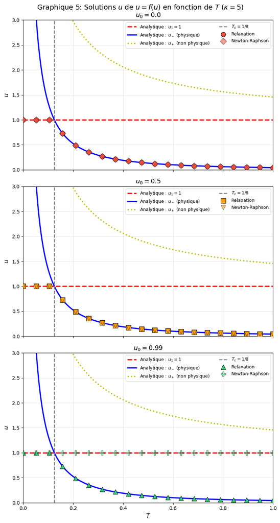

```python
# --- Graphique : solutions u vs T ---
fig, axes = plt.subplots(3, 1, figsize=(8, 15), sharex=True)

markers_r = ['o', 's', '^']
markers_n = ['D', 'v', 'P']
colors    = ['#E74C3C', '#F39C12', '#2ECC71']

# Courbes analytiques sur grille fine
T_fine  = np.linspace(1e-6, 1, 500)
u1_fine     = [1.0 for T in T_fine]
u_moins_fine = [(1 + 2*T - 2*np.sqrt(T*(T+1))) / (4*T) for T in T_fine]
u_plus_fine  = [(1 + 2*T + 2*np.sqrt(T*(T+1))) / (4*T) for T in T_fine]

for idx, (u0, ax) in enumerate(zip(u0_vals, axes)):

    # Courbes analytiques
    ax.plot(T_fine, u1_fine,      'r--', lw=2.5, label='Analytique : $u_1 = 1$')
    ax.plot(T_fine, u_moins_fine, 'b-',  lw=2.5, label='Analytique : $u_-$ (physique)')
    ax.plot(T_fine, u_plus_fine,  'y:',  lw=2.5, label='Analytique : $u_+$ (non physique)')
    ax.axvline(1/8, color='gray', ls='--', lw=1.8, label='$T_c = 1/8$')

    # Points numériques (directement u, pas R_inf)
    ax.scatter(T_dist, resultats_relaxation[u0], marker=markers_r[idx], s=90,
               color=colors[idx], edgecolors='k', lw=0.7, zorder=5,
               label='Relaxation')
    ax.scatter(T_dist, resultats_NewtonRaphson[u0], marker=markers_n[idx], s=90,
               color=colors[idx], edgecolors='k', lw=0.7, zorder=5, alpha=0.55,
               label='Newton-Raphson')

    ax.set_title(f'$u_0 = {u0}$', fontsize=13)
    ax.set_ylabel('$u$', fontsize=12)
    ax.set_xlim(0, 1)
    ax.set_ylim(0, 3)
    ax.legend(fontsize=9, loc='upper right', ncol=2)
    ax.grid(True, alpha=0.3)

axes[2].set_xlabel('$T$', fontsize=12)
fig.suptitle('Graphique 5: Solutions $u$ de $u = f(u)$ en fonction de $T$ $(\\kappa = 5)$',
             fontsize=14)
plt.tight_layout()
plt.show()
```

Nous remarquons que pour $u_0=0$ et $u_0=0,5$ les résultats sont comparables. Comme attendu (d'après la question 3.b) lorsque $T<T_c$ la plus petite solution analytique devient $u=1$, les deux modèles coïncident bien avec la courbe $u=1$. Lorsque $T>T_c$, les deux modèles coïncident avec la courbe de la solution $u_-$, ce qui correspond bien au conclusion de la 3.b où nous avions définit $u_-$ comme l'unique solution physique lorque $T>T_c$.  
Plus simplement, les solutions numériques coïncident avec les solutions analytiques **physiques** $\forall \,\, T \in [0,1]$, telles qu'établies à la 3.b.  
Pourquoi les solutions numériques des méthodes par relaxation et Newton-Raphson, qui pourraient suivre n'importe quelles des trois solutions analytiques de $(1.13)$, coïncident pour tout $T$ aux solutions physique ? Traçons $u=f(u)$ ainsi que la dérivée $f'(u)$, pour pouvoir analyser les points fixes de $f(u)$.

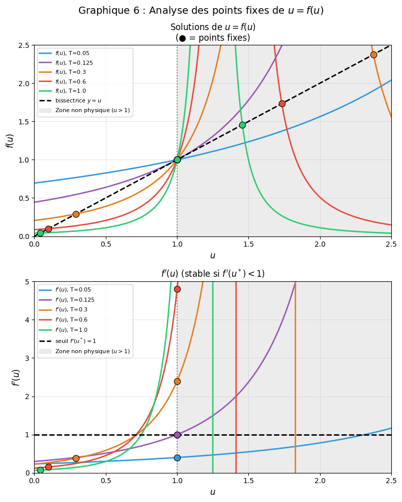

```python
# === Graphique : u=f(u) et f'(u) ===
fig, axes = plt.subplots(2, 1, figsize=(8, 10))

u_arr = np.linspace(0, 2.5, 500)
T_show = [0.05, 0.125, 0.3, 0.6, 1.0]
colors_T = ['#3498DB', '#9B59B6', '#E67E22', '#E74C3C', '#2ECC71']

def f_prime(u, T):      #dérivée f'(u)
    A = T * (kappa - 1)
    return 2*A / (1 + A*(1-u))**3

#---Haut : u = f(u)---
for T, col in zip(T_show, colors_T):
    axes[0].plot(u_arr, [f(u, T) for u in u_arr], color=col, lw=2, label=f'$f(u)$, T={T}')

    u_moins = (1 + 2*T - 2*np.sqrt(T*(T+1))) / (4*T)
    u_plus  = (1 + 2*T + 2*np.sqrt(T*(T+1))) / (4*T)

    for pt in [1.0, u_moins, u_plus]:  # ← on ajoute u_plus
        if 0 <= pt <= 2.5:             # ← on étend la condition à 2.5
            axes[0].scatter([pt], [pt], color=col, s=80, zorder=5, edgecolors='k', lw=0.8)

axes[0].plot(u_arr, u_arr, 'k--', lw=2, label='bissectrice $y = u$')
axes[0].set_xlabel('$u$', fontsize=12)
axes[0].set_ylabel('$f(u)$', fontsize=12)
axes[0].set_title("Solutions de $u = f(u)$\n(● = points fixes)", fontsize=12,)
axes[0].set_xlim(0, 2.5)
axes[0].set_ylim(0, 2.5)
axes[0].axvspan(1, 2.5, alpha=0.15, color='gray', label='Zone non physique ($u > 1$)')
axes[0].axvline(1, color='gray', ls=':', lw=1.5)
axes[0].legend(fontsize=8)
axes[0].grid(True, alpha=0.3)

#---Bas : f'(u)---
for T, col in zip(T_show, colors_T):
    axes[1].plot(u_arr, [f_prime(u, T) for u in u_arr], color=col, lw=2, label=f"$f'(u)$, T={T}")

    u_moins = (1 + 2*T - 2*np.sqrt(T*(T+1))) / (4*T)
    u_plus  = (1 + 2*T + 2*np.sqrt(T*(T+1))) / (4*T)

    for pt in [1.0, u_moins, u_plus]:  # ← on ajoute u_plus
        if 0 <= pt <= 2.5:             # ← on étend la condition à 2.5
            axes[1].scatter([pt], [f_prime(pt, T)], color=col, s=80,
                            zorder=5, edgecolors='k', lw=0.8)

axes[1].axhline(1, color='k', ls='--', lw=2, label="seuil $f'(u^*) = 1$")
axes[1].set_xlabel('$u$', fontsize=12)
axes[1].set_ylabel("$f'(u)$", fontsize=12)
axes[1].set_title("$f'(u)$ (stable si $f'(u^*) < 1$)", fontsize=12)
axes[1].set_xlim(0, 2.5)
axes[1].set_ylim(0, 5)
axes[1].axvspan(1, 2.5, alpha=0.15, color='gray', label='Zone non physique ($u > 1$)')
axes[1].axvline(1, color='gray', ls=':', lw=1.5)
axes[1].legend(fontsize=8)
axes[1].grid(True, alpha=0.3)

fig.suptitle("Graphique 6 : Analyse des points fixes de $u = f(u)$", fontsize=14,)
plt.tight_layout()
plt.show()
```

## Graphique de $f'(u)$ :

Lorsque $T>T_c$,

- $f'(u_-)<1$, $u_-$ est stable.
- $f'(u=1)>1$, $u=1$ est instable.

Ainsi les points fixes $u=1$ qui sont stables pour $T\leq T_c$ deviennet instables pour $T>T_c$. Les convergeance se faisant vers les points fixes stables, les méthode numériques coïncident avec $u=1$ tant que $T\leq T_c$, puis avec les uniques points fixes stables physiquement $u_-1$ lorque $T>T_c$. Mais cette notion de points fixes ne traduit que la convergeance dans la méthode par relaxation, un cas particulier visible sur le graphique 8 permet d'expliquer la méthode de Newton-Raphson.

## $u=0,99$

Mais pour $u=0,99$ c'est différent.  
La méthode par relaxation présente les même conclusion que précédement.  
Mais en ce qui concerne la méthode Newton-Raphson nous remarquons que les solutions coïncident en tout T avec $u=1$. La méthode ne semble donc pas fonctionner pour un $u$ trop élevé.  
Faisons des graphiques pour visualiser par itération la convergence des tangentes de Newton-Raphson.

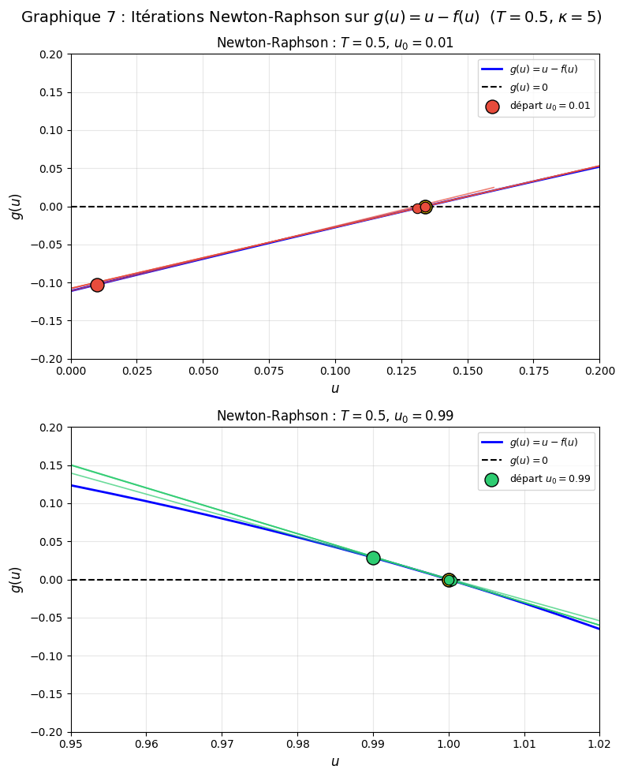

```python
fig, axes = plt.subplots(2, 1, figsize=(8, 10))

T = 0.5
u_arr_full = np.linspace(0, 1.05, 500)

u_moins = (1 + 2*T - 2*np.sqrt(T*(T+1))) / (4*T)  # ≈ 0.134

# Intervalles adaptés à chaque u0
configs = [
    {'u0': 0.01, 'col': '#E74C3C', 'xlim': (0, 0.2),  'ylim': (-0.2, 0.2), 'titre': '$u_0=0.01$'},
    {'u0': 0.99, 'col': '#2ECC71', 'xlim': (0.95, 1.02), 'ylim': (-0.2, 0.2), 'titre': '$u_0=0.99$'},
]

for ax, cfg in zip(axes, configs):
    # Courbe g(u)
    ax.plot(u_arr_full, [g(u, T) for u in u_arr_full], 'b-', lw=2, label='$g(u) = u - f(u)$')
    ax.axhline(0, color='k', ls='--', lw=1.5, label='$g(u) = 0$')

    # Points fixes
    for pt in [u_moins, 1.0]:
        ax.scatter([pt], [0], color='gold', s=150, zorder=6, edgecolors='k', lw=1.2)

    # Itérations Newton-Raphson
    u = cfg['u0']
    for i in range(10):
        gu  = g(u, T)
        gpu = g_prime(u, T)
        u_new = u - gu / gpu

        # Tangente locale
        u_tang = np.linspace(u - 0.15, u + 0.15, 100)
        ax.plot(u_tang, gu + gpu*(u_tang - u), color=cfg['col'], lw=1.2, alpha=0.7)
        ax.scatter([u], [gu], color=cfg['col'], s=80, zorder=7, edgecolors='k', lw=0.8)

        # Ligne verticale vers l'axe
        ax.plot([u_new, u_new], [0, g(u_new, T)], color=cfg['col'],
                lw=0.8, ls=':', alpha=0.5)

        if abs(u_new - u) < 1e-10:
            break
        u = u_new

    ax.scatter([cfg['u0']], [g(cfg['u0'], T)], color=cfg['col'], s=150,
               zorder=8, edgecolors='k', label=f"départ {cfg['titre']}")

    ax.set_xlabel('$u$', fontsize=12)
    ax.set_ylabel('$g(u)$', fontsize=12)
    ax.set_title(f"Newton-Raphson : $T={T}$, {cfg['titre']}", fontsize=12)
    ax.set_xlim(cfg['xlim'])
    ax.set_ylim(cfg['ylim'])
    ax.legend(fontsize=9)
    ax.grid(True, alpha=0.3)

fig.suptitle("Graphique 7 : Itérations Newton-Raphson sur $g(u) = u - f(u)$  ($T=0.5$, $\\kappa=5$)",
             fontsize=14)
plt.tight_layout()
plt.show()
```

La méthode Newton-Raphson cherche les zéros de la fonction $g(u)$. Pour converger vers ces zéros, Newton-Raphson suit les tangentes, au voisinage de $u=0,95$ la pente est négative, la convergence se fait donc vers le zéro le plus grand, qui se situe à $u=1$. Alors qu'au voisinage de 0,01 la pente est positive, la convergence se fait vers le zéro le plus petit $u_-$.

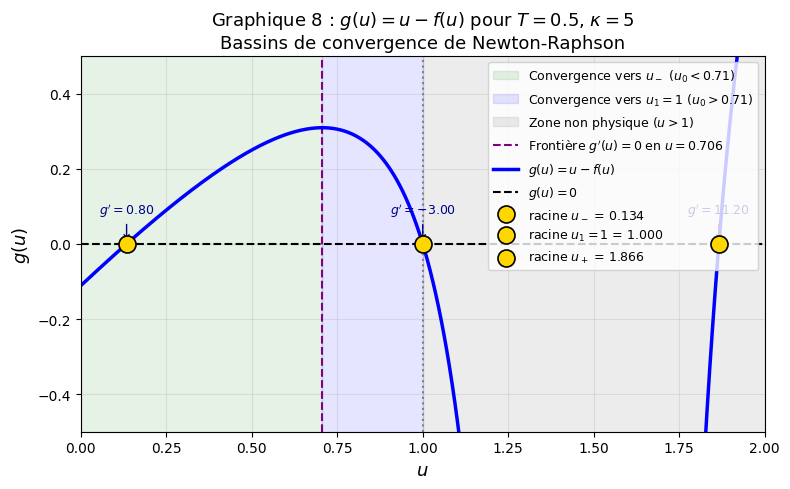

```python
fig, ax = plt.subplots(figsize=(8, 5))

u_arr = np.linspace(0, 2, 500)
T = 0.5

u_moins = (1 + 2*T - 2*np.sqrt(T*(T+1))) / (4*T)
u_plus  = (1 + 2*T + 2*np.sqrt(T*(T+1))) / (4*T)

# Frontière entre les deux bassins de convergence
from scipy.optimize import brentq
u_frontier = brentq(lambda u: g_prime(u, T), 0.2, 0.99)

# Zones de convergence
ax.axvspan(0, u_frontier, alpha=0.1, color='green',
           label=f'Convergence vers $u_-$ ($u_0 < {u_frontier:.2f}$)')
ax.axvspan(u_frontier, 1, alpha=0.1, color='blue',
           label=f'Convergence vers $u_1=1$ ($u_0 > {u_frontier:.2f}$)')

# Zone non physique
ax.axvspan(1, 2, alpha=0.15, color='gray', label='Zone non physique ($u > 1$)')
ax.axvline(1, color='gray', ls=':', lw=1.5)

# Frontière
ax.axvline(u_frontier, color='purple', ls='--', lw=1.5,
           label=f"Frontière $g'(u)=0$ en $u={u_frontier:.3f}$")

# Courbe g(u)
ax.plot(u_arr, [g(u, T) for u in u_arr], 'b-', lw=2.5, label='$g(u) = u - f(u)$')
ax.axhline(0, color='k', ls='--', lw=1.5, label='$g(u) = 0$')

# Points fixes
for pt, nom in [(u_moins, '$u_-$'), (1.0, '$u_1=1$'), (u_plus, '$u_+$')]:
    ax.scatter([pt], [0], color='gold', s=150, zorder=6,
               edgecolors='k', lw=1.2, label=f'racine {nom} = {pt:.3f}')

# Valeurs de g' aux racines
for pt in [u_moins, 1.0, u_plus]:
    gpu = g_prime(pt, T)
    ax.annotate(f"$g'={gpu:.2f}$", xy=(pt, 0),
                xytext=(pt, 0.08), fontsize=9,
                ha='center', color='darkblue',
                arrowprops=dict(arrowstyle='->', color='darkblue'))

ax.set_xlabel('$u$', fontsize=13)
ax.set_ylabel('$g(u)$', fontsize=13)
ax.set_title(f'Graphique 8 : $g(u) = u - f(u)$ pour $T={T}$, $\\kappa=5$\n'
             f'Bassins de convergence de Newton-Raphson',
             fontsize=13)
ax.set_xlim(0, 2)
ax.set_ylim(-0.5, 0.5)
ax.legend(fontsize=9, loc='upper right')
ax.grid(True, alpha=0.3)
plt.tight_layout()
plt.show()
```

Le graphique 8 permet d'avoir une vision globale sur g (dans un plus grand intervalle) des phénomènes mis en lumière par les graphiques 7 (plus petit intervalle).  
Dans la zone verte, $g'(u)>0$, la pente est positive, la convergence se fait vers $u_-$. Dans la zone bleue, $g'(u)<0$, la pente est négative, la convergence se fait vers $u=1$.  
Pour la méthode de Newton-Raphson il faut s'assurer de prendre des $u_0$ qui conviennent. Par exemple dans notre cas et pour $T=0,5$, il faut $u_0<0,706$ qui est la valeur où $g'(u)$ devient négative.

## Références

### Documentation et cours

4. **Notes de cours PHY-3500** — Physique numérique (H26)  
   ↳ Professeurs : Antoine Allard, Thomas Labbé  
   *Université Laval*
5. **Énoncé du TP3**  
   ↳ Responsable: Antoine Allard  
   *Document de référence pour ce travail*

PHY-3500 — Physique numérique (H26) — TP 3

Alex Baker • Justine Jean • Nerimantas Caillat